# Franasiak et al. (2014) Analysis

Michael Whitehouse

Analysis of Franasiak et al. (2014). When fitting simple age vs. aneuploidy model to KindLabs data, I used the polynomial given in the text of the paper as a reference—but noticed the curve it graphed was visibly different than the one shown in figure 2A of the paper in the oldest age range.

Copied [table 1](https://www.fertstert.org/action/showFullTableHTML?isHtml=true&tableId=tbl1&pii=S0015-0282%2813%2903257-3) to CSV (by LLM + checked by hand).

```r
t1_raw <- read_csv("data/franasiak_table_1.csv")
t1 <- t1_raw %>% janitor::clean_names()
```

[output not shown]

There’s an error in the calculated aneuploidy rate in the table for age 45:

```r
t1_error <- t1_raw %>%
  select(1:8) %>%
  gt() %>%
  tab_header(
    title = "Table 1: PGT-A Aneuploidy Rates by Age",
    subtitle = "Franasiak et al. (2014)"
  ) %>%
  # highlight aneuploidy for age 45
  tab_style(
    style = list(
      cell_fill(color = "lightcoral"),
      cell_text(weight = "bold")
    ),
    locations = cells_body(
      columns = 8,
      rows = 24
    )
  )

t1_error
```

Table 1: PGT-A Aneuploidy Rates by Age

Franasiak et al. (2014)

| Age (y) | Oocytes retrieved (¬µ ¬± SEM) | Cohorts of embryos evaluated (n) | No. of biopsies evaluated (n) | Euploid n | Euploid Percentage of total | Aneuploid n | Aneuploid Percentage of total |
| --- | --- | --- | --- | --- | --- | --- | --- |
| 22 | 23.5 ¬± 3.5 | 9 | 72 | 40 | 55.6 | 32 | 44.4 |
| 23 | 19.3 ¬± 1.7 | 12 | 76 | 45 | 59.2 | 31 | 40.8 |
| 24 | 21.5 ¬± 2.1 | 13 | 79 | 57 | 72.2 | 22 | 27.8 |
| 25 | 12.9 ¬± 1.1 | 17 | 90 | 50 | 55.6 | 40 | 44.4 |
| 26 | 15.1 ¬± 1.1 | 29 | 175 | 132 | 75.4 | 43 | 24.6 |
| 27 | 16.2 ¬± 0.6 | 36 | 240 | 175 | 72.9 | 65 | 27.1 |
| 28 | 13.0 ¬± 0.7 | 57 | 335 | 259 | 77.3 | 76 | 22.7 |
| 29 | 13.9 ¬± 0.4 | 106 | 585 | 464 | 79.3 | 121 | 20.7 |
| 30 | 12.9 ¬± 0.4 | 126 | 802 | 616 | 76.8 | 186 | 23.2 |
| 31 | 13.9 ¬± 0.3 | 164 | 862 | 595 | 69.0 | 267 | 31.0 |
| 32 | 11.1 ¬± 0.2 | 193 | 1023 | 705 | 68.9 | 318 | 31.1 |
| 33 | 13.9 ¬± 0.4 | 231 | 1324 | 913 | 69.0 | 411 | 31.0 |
| 34 | 13.7 ¬± 0.4 | 221 | 1156 | 794 | 68.7 | 362 | 31.3 |
| 35 | 11.6 ¬± 0.3 | 226 | 1222 | 800 | 65.5 | 422 | 34.5 |
| 36 | 12.8 ¬± 0.3 | 267 | 1284 | 828 | 64.5 | 456 | 35.5 |
| 37 | 10.1 ¬± 0.3 | 257 | 1153 | 662 | 57.4 | 491 | 42.6 |
| 38 | 8.7 ¬± 0.2 | 280 | 1123 | 585 | 52.1 | 538 | 47.9 |
| 39 | 10.5 ¬± 0.2 | 272 | 1008 | 475 | 47.1 | 533 | 52.9 |
| 40 | 11.2 ¬± 0.3 | 249 | 953 | 398 | 41.8 | 555 | 58.2 |
| 41 | 9.2 ¬± 0.3 | 234 | 750 | 233 | 31.1 | 517 | 68.9 |
| 42 | 8.7 ¬± 0.2 | 150 | 453 | 113 | 24.9 | 340 | 75.1 |
| 43 | 6.0 ¬± 0.3 | 79 | 217 | 36 | 16.6 | 181 | 83.4 |
| 44 | 5.7 ¬± 0.2 | 41 | 85 | 10 | 11.8 | 75 | 88.2 |
| 45 | 8.0 ¬± 0.4 | 22 | 39 | 4 | 15.7 | 35 | 84.3 |
| 46 | 11.8 ¬± 0.5 | 4 | 43 | 12 | 27.9 | 31 | 72.1 |
| 47 | 6.3 ¬± 0.3 | 4 | 17 | 0 | 0.0 | 17 | 100.0 |
| 48 | 2 | 1 | 1 | 0 | 0.0 | 1 | 100.0 |
| 49 | 4 | 1 | 2 | 0 | 0.0 | 2 | 100.0 |

```r
35/39
```

```
[1] 0.8974359
```

35/39 (89.7%) of embryos biopsied for 45yo patients were aneuploid, not 84.3% as reported in the paper.

The paper gives this regression formula to predict age vs. aneuploidy:

> The relationship between aneuploidy and age was best predicted by a fifth order polynomial: [Percent aneuploid = 1,965 - 278.9 * Age + 16.41 * (Age)<sup>2</sup> - 0.4922 * (Age)<sup>3</sup> + 0.007451 * (Age)<sup>4</sup> - 0.000044692 * (Age)<sup>5</sup>]. The relationship was statistically significant (*P*<1*10<sup>-6</sup>). **This polynomial regression line is superimposed on the graph of aneuploidy vs. age in Figure 2A.**

```r
franasiak_aneuploidy <- function(age) {
  percent_value <- 1965 -
                   278.9 * age +
                   16.41 * (age^2) -
                   0.4922 * (age^3) +
                   0.007451 * (age^4) -
                   0.000044692 * (age^5)
  return(percent_value / 100) # Convert to proportion (0-1 scale)
}
```

However, [fig. 2A](https://www.fertstert.org/cms/10.1016/j.fertnstert.2013.11.004/asset/12d710e6-4c2a-4dd4-ab32-bbae878dd6b5/main.assets/gr2_lrg.jpg) shows all patients 45 and older binned into a “45+” age group. It’s not clear how they (or anyone) would draw their polynomial onto this graph.

Here’s their data binned into the same “45+” age group, to try to recreate their figure.

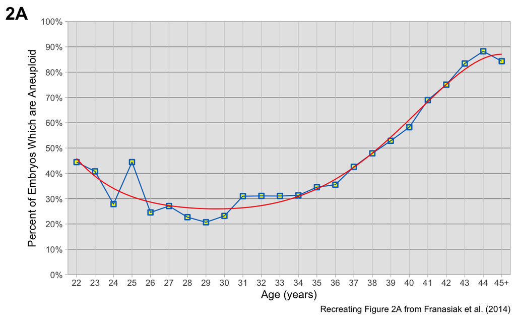

```r
t1_binned <- t1 %>%
  # group all ages 45 and above into a single group
  mutate(age_binned = ifelse(age_y >= 45, 45, age_y)) %>%
  group_by(age_binned) %>%
  summarize(aneuploidy_rate = sum(aneuploid_n) / sum(no_of_biopsies_evaluated_n))

t1_binned %>%
  ggplot(aes(x = age_binned, y = aneuploidy_rate)) +
  geom_point(shape = 22, stroke = 1, size = 2, color = "#0170C4", fill = "#fefd03") +
  geom_line(color = "#0170C4") +
  # fit with 5th order polynomial
  stat_smooth(method = "lm", formula = y ~ poly(x, 5), color = "#FD0909", se = FALSE, linewidth = .5) +
  scale_x_continuous(breaks = seq(22, 45), expand = c(.02,.02), labels = c(as.character(seq(22,44)),"45+")) +
  scale_y_continuous(labels = scales::percent, breaks = seq(0, 1, 0.1), expand = c(0,0)) +
  coord_cartesian(ylim = c(0, 1), xlim = c(22, 45)) +
  labs(
    caption = "Recreating Figure 2A from Franasiak et al. (2014)",
    x = "Age (years)",
    y = "Percent of Embryos Which are Aneuploid",
    tag = "2A"
  )
```

```r
NA
```

```r
# 5th order polynomial fit to binned data
m1_binned <- lm(aneuploidy_rate ~ poly(age_binned, 5), data = t1_binned)

summary(m1_binned)
```

```
Call:
lm(formula = aneuploidy_rate ~ poly(age_binned, 5), data = t1_binned)

Residuals:
      Min        1Q    Median        3Q       Max
-0.061972 -0.027743 -0.000801  0.020207  0.136446

Coefficients:
                     Estimate Std. Error t value Pr(>|t|)
(Intercept)           0.44657    0.00933  47.863  < 2e-16 ***
poly(age_binned, 5)1  0.78233    0.04571  17.116 1.39e-12 ***
poly(age_binned, 5)2  0.59675    0.04571  13.056 1.28e-10 ***
poly(age_binned, 5)3 -0.08389    0.04571  -1.835    0.083 .
poly(age_binned, 5)4 -0.05496    0.04571  -1.202    0.245
poly(age_binned, 5)5 -0.06672    0.04571  -1.460    0.162
---
Signif. codes:  0 ‘***’ 0.001 ‘**’ 0.01 ‘*’ 0.05 ‘.’ 0.1 ‘ ’ 1

Residual standard error: 0.04571 on 18 degrees of freedom
Multiple R-squared:  0.9631,    Adjusted R-squared:  0.9529
F-statistic: 94.07 on 5 and 18 DF,  p-value: 2.944e-12
```

Paper could have reported they binned all patients 45 and above, and given this polynomial model …

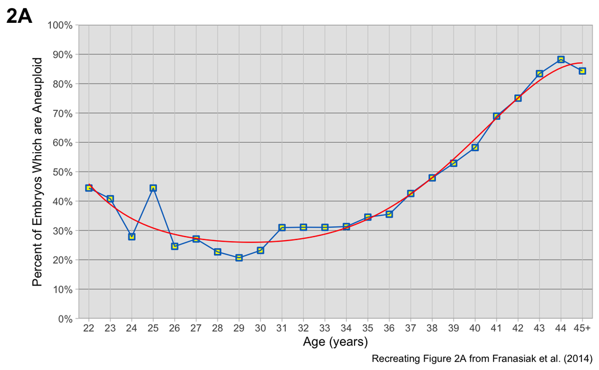

```r
t1_binned %>%
  ggplot(aes(x = age_binned, y = aneuploidy_rate)) +
  geom_point(shape = 22, stroke = 1, size = 2, color = "#0170C4", fill = "#fefd03") +
  geom_line(color = "#0170C4") +
  #plot model predictions of m1_binned
  geom_function(fun =  function(x) predict(m1_binned, data.frame(age_binned = x)), color = "#FD0909", linewidth = .5) +
  scale_x_continuous(breaks = seq(22, 45), expand = c(.02,.02), labels = c(as.character(seq(22,44)),"45+")) +
  scale_y_continuous(labels = scales::percent, breaks = seq(0, 1, 0.1), expand = c(0,0)) +
  coord_cartesian(ylim = c(0, 1), xlim = c(22, 45)) +
  labs(
    caption = "Recreating Figure 2A from Franasiak et al. (2014)",
    x = "Age (years)",
    y = "Percent of Embryos Which are Aneuploid",
    tag = "2A"
  )
```

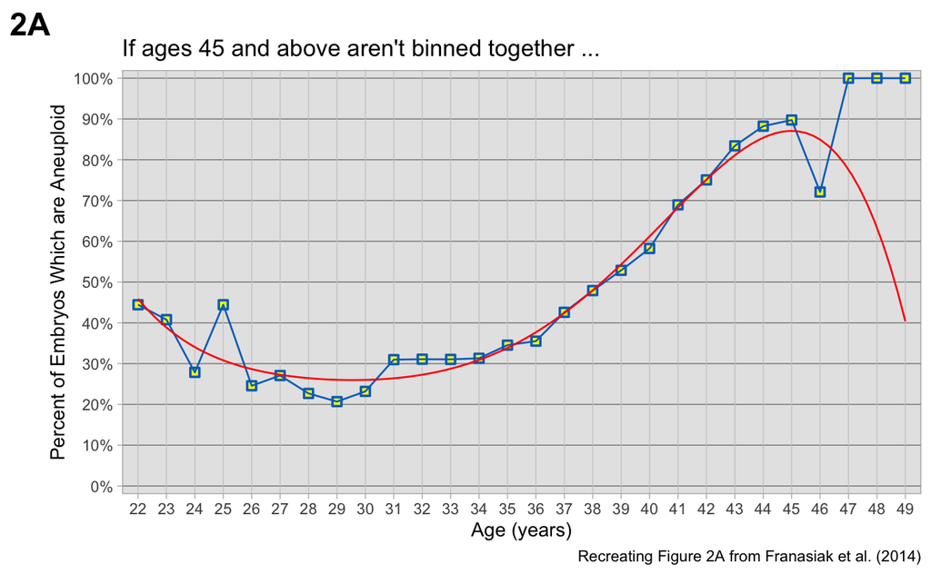

```r
t1 %>%
  ggplot(aes(x = age_y, y = aneuploid_n / no_of_biopsies_evaluated_n)) +
  geom_point(shape = 22, stroke = 1, size = 2, color = "#0170C4", fill = "#fefd03") +
  geom_line(color = "#0170C4") +
  #plot model predictions of m1_binned
  geom_function(fun =  function(x) predict(m1_binned, data.frame(age_binned = x)), color = "#FD0909", size = .5) +
  scale_x_continuous(breaks = seq(22, 49), expand = c(.02,.02)) +
  scale_y_continuous(labels = scales::percent, breaks = seq(0, 1, 0.1), expand = c(0,.02)) +
  coord_cartesian(ylim = c(0, 1), xlim = c(22, 49)) +
  labs(
    title = "If ages 45 and above aren't binned together ... ",
    caption = "Recreating Figure 2A from Franasiak et al. (2014)",
    x = "Age (years)",
    y = "Percent of Embryos Which are Aneuploid",
    tag = "2A"
  )
```

That looks pretty silly. Here’s both polynomials on the same graph, without age binning:

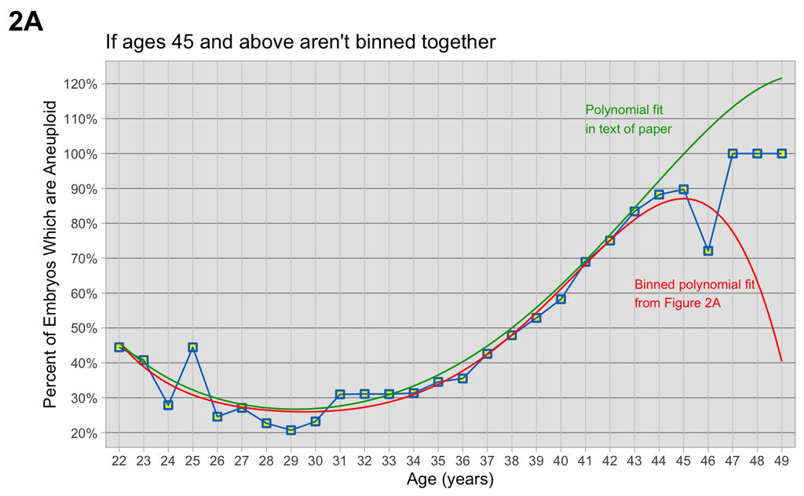

```r
t1 %>%
  ggplot(aes(x = age_y, y = aneuploid_n / no_of_biopsies_evaluated_n)) +
  geom_point(shape = 22, stroke = 1, size = 2, color = "#0170C4", fill = "#fefd03") +
  geom_line(color = "#0170C4") +
  #plot model predictions of m1_binned
  geom_function(fun =  function(x) predict(m1_binned, data.frame(age_binned = x)), color = "#FD0909", linewidth = .5) +
  # label line
  annotate(geom = "text", x = 43, y = 0.6, label = "Binned polynomial fit\nfrom Figure 2A",
    color = "#FD0909", size = 3, hjust = 0) +
  geom_function(fun = franasiak_aneuploidy, color = "#00A000", linewidth = .5) +
  annotate(geom = "text", x = 41, y = 1.1, label = "Polynomial fit \nin text of paper",color = "#00A000", size = 3, hjust = 0) +
  scale_x_continuous(breaks = seq(22, 49), expand = c(.02,.02)) +
  scale_y_continuous(labels = scales::percent, breaks = seq(0, 1.2, 0.1)) +
  # coord_cartesian(ylim = c(0, 1), xlim = c(22, 49)) +
  labs(
    title = "If ages 45 and above aren't binned together",
    x = "Age (years)",
    y = "Percent of Embryos Which are Aneuploid",
    tag = "2A"
  )
```

Both of these are obviously bad models of aneuploidy in patients older than 44.

Here’s what we would have seen in Fig. 2A without any binning of older patients.

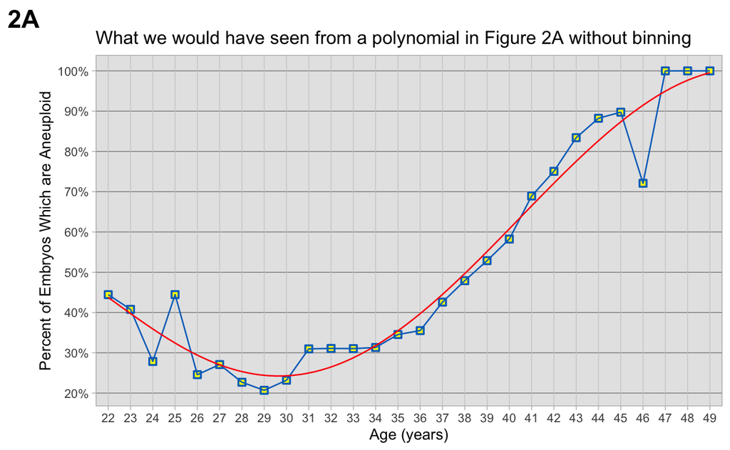

```r
t1 %>%
  ggplot(aes(x = age_y, y = aneuploid_n / no_of_biopsies_evaluated_n)) +
  geom_point(shape = 22, stroke = 1, size = 2, color = "#0170C4", fill = "#fefd03") +
  geom_line(color = "#0170C4") +
  #plot best fit line of 5th order polynomial
  geom_smooth(method = "lm", formula = y ~ poly(x, 5), color = "#FD0909", se = FALSE, size = .5) +
  scale_x_continuous(breaks = seq(22, 49), expand = c(.02,.02)) +
  scale_y_continuous(labels = scales::percent, breaks = seq(0, 1.2, 0.1)) +
  # coord_cartesian(ylim = c(0, 1), xlim = c(22, 49)) +
  labs(
    title = "What we would have seen from a polynomial in Figure 2A without binning",
    x = "Age (years)",
    y = "Percent of Embryos Which are Aneuploid",
    tag = "2A"
  )
```

… which shows at a glance that the data for their 46yo patients (4 cycles, 43 embryos?!?) is very unusual. This also makes the polynomial a worse fit to the data in the age ranges where it should be most useful, i.e. between 30 and 45. The extremes of the age range are where the data is most sparse—but those points have a whole lot of leverage in a polynomial fit.

In their paper they conclude:

> The prevalence of aneuploidy rose steadily from age 31 through age 43, then plateaued at approximately 85%.

That claim is just not justified by their data. Here’s something closer to what we SHOULD have seen from a graph like this:

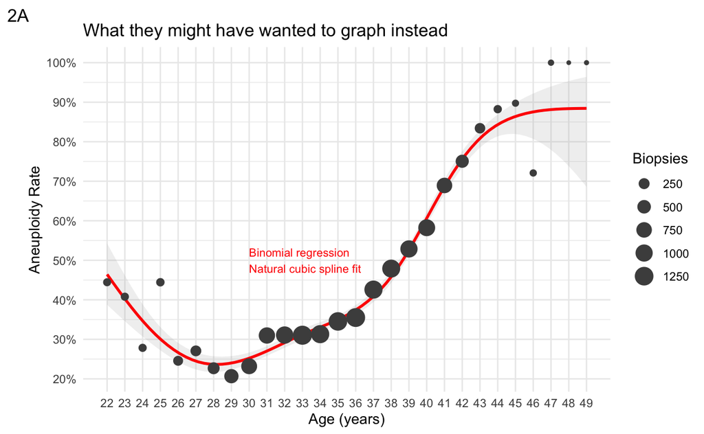

```r
theme_set(theme_minimal())

alpha <- 0.05

t1_ci <- t1 %>%
    mutate(
    aneuploidy_rate = aneuploid_n / no_of_biopsies_evaluated_n,
    ymin = qbeta(alpha / 2, aneuploid_n, no_of_biopsies_evaluated_n - aneuploid_n + 1),
    ymax = qbeta(1 - alpha / 2, aneuploid_n + 1, no_of_biopsies_evaluated_n - aneuploid_n)
  ) %>%
  # Handle edge cases where the rate is 0 or 1
  mutate(
    ymin = if_else(aneuploid_n == 0, 0, ymin),
    ymax = if_else(aneuploid_n == no_of_biopsies_evaluated_n, 1, ymax)
  )

t1_ci%>%
  ggplot(aes(x = age_y, y = aneuploidy_rate)) +
  geom_smooth(
    method = "glm",
    method.args = list(family = "binomial"),
    aes(weight = no_of_biopsies_evaluated_n),
    formula = y ~ splines::ns(x, df = 5),
    se = TRUE,
    level = 0.95,
    alpha = 0.15,
    color = "red"
  ) +
  annotate(
    geom = "text",
    x = 30,
    y = 0.5,
    label = "Binomial regression\nNatural cubic spline fit",
    color = "red",
    size = 3,
    hjust = 0
  ) +
  # Points and error bars
  geom_point(aes(size = no_of_biopsies_evaluated_n), color = "grey30") +
  scale_y_continuous(labels = scales::percent, breaks = seq(0, 1, 0.1)) +
  scale_x_continuous(breaks = seq(22, 49), minor_breaks = NULL) +
  labs(
    title = "What they might have wanted to graph instead",
    x = "Age (years)",
    y = "Aneuploidy Rate",
    tag = "2A",
    size = "Biopsies"
  )
```

… with a wide uncertainty band (95% CI for model predictions in this case) for the top age groups where data were sparse.

Or really no need to show a model fit, can just put error bars for the measured rates:

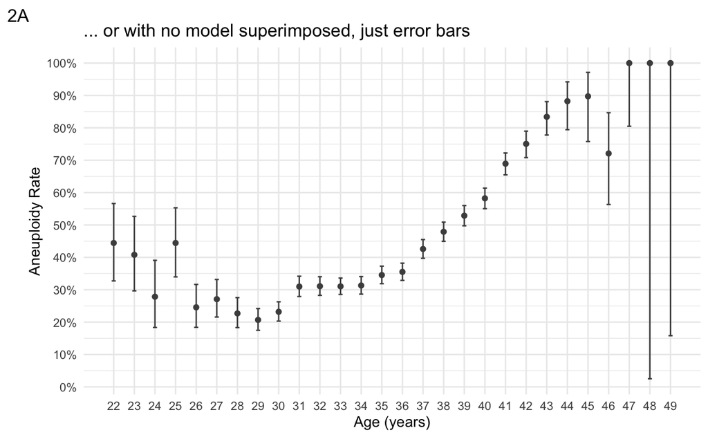

```r
t1_ci %>%
  ggplot(aes(x = age_y, y = aneuploidy_rate)) +
  # Points and error bars
  geom_point(color = "grey30") +
  geom_errorbar(
    aes(ymin = ymin, ymax = ymax),
    width = 0.2,
    color = "grey30"
  ) +
  scale_y_continuous(labels = scales::percent, breaks = seq(0, 1, 0.1)) +
  scale_x_continuous(breaks = seq(22, 49), minor_breaks = NULL) +
  labs(
    title = "... or with no model superimposed, just error bars",
    x = "Age (years)",
    y = "Aneuploidy Rate",
    tag = "2A",
    size = "Biopsies"
  )
```

Overall, I’m very surprised that this famous graph was fudged. I think it meaningfully affected their analysis and likely contributed to their overstated conclusions in the paper. Two thoughts:

1. You can’t arrive at reasonable conclusions about these data without seeing the uncertainty in the model estimates and/or sample sizes in each age bin.
2. This is a good reminder of how [many little choices are made in each data analysis](https://journals.sagepub.com/doi/full/10.1177/2515245917747646#fig2-2515245917747646)—sometimes called “[researcher degrees of freedom](https://en.wikipedia.org/wiki/Researcher_degrees_of_freedom)”. Why bin together patients 45 and older? Why not try to justify this in the text of the paper?

I think a better rephrasing of their conclusions might be:

> Aneuploidy is low (<35%) in patients age 26 to 34 but rises steadily as a function of age from roughly 35% at age 35, to roughly 90% at age 45. No euploid embryos were observed in patients 47 and older. However, we cannot draw strong conclusions about aneuploidy rates in patients younger than 26 or older than 45 given how few embryos were tested from patients in those age ranges.